# U6. El retorno del peronismo

Pacto Social y crisis · Clases 23–24

Sebastian Freille

Universidad Nacional de Córdoba

# Apertura

## Dónde quedamos

- La Revolución Argentina terminó sin consolidar la estabilidad ni su proyecto político. La salida electoral devolvió al peronismo al gobierno en **1973**.
- Quedaban capacidades productivas y una economía que había crecido durante la década anterior. También inflación creciente y demandas distributivas postergadas.
- El nuevo gobierno intentó recuperar salarios y estabilizar mediante un acuerdo entre el Estado, la CGT y la CGE: el **Pacto Social**.

**Idea clave**

El acuerdo podía cambiar expectativas y detener remarcaciones. Para durar, necesitaba resolver cómo ajustar precios relativos, financiar al Estado y distribuir los costos de los shocks externos.

Gerchunoff y Llach (2007), cierre del cap. 7 y cap. 8, pp. 334–347; Arnaudo (1979), pp. 25–39.

## La pregunta de hoy

> ¿Por qué el Pacto Social pudo frenar tan rápido la inflación y, sin embargo, no logró evitar la crisis de 1975?

**Dos horizontes**

Un programa puede tener **éxito inicial** y problemas de continuidad. Explicar el primero no obliga a negar los segundos, ni conocer el desenlace vuelve irrelevante lo conseguido al comienzo.

## Mapa de las clases

1. **Bloque 1. El retorno:** política, economía y proyecto de Gelbard.
2. **Bloque 2. Los depósitos:** la reforma de 1973 y la comparación con 1946.
3. **Bloque 3. El Pacto Social:** medidas, resultados y lectura de Arnaudo.
4. **Bloque 4. La ruptura:** flexibilización, Rodrigazo y crisis de 1976.

Programa 2024, capítulo 6, apartado 6.1. Clase 23: bloques 1–2. Clase 24: bloques 3–4 y cierre, incluidos en esta misma presentación.

# Bloque 1. El retorno

## [1.1] Cuatro presidentes

| Presidencia | Período | Problema político |
| --- | --- | --- |
| **Cámpora** | Mayo–julio de 1973 | Regreso del peronismo y expectativas de transformación |
| **Lastiri** | Julio–octubre de 1973 | Transición hacia una nueva elección |
| **Perón** | Octubre de 1973–julio de 1974 | Intento de arbitrar dentro y fuera del movimiento |
| **Isabel Perón** | Julio de 1974–marzo de 1976 | Disputas internas y creciente debilidad del gobierno |

- **José Ber Gelbard** continuó como ministro bajo los cuatro presidentes. La rotación política no produjo un cambio inmediato de programa económico.

Gerchunoff y Llach (2007), pp. 334–337.

## [1.2] La coalición económica

- Gelbard provenía de la **Confederación General Económica**, vinculada al empresariado nacional. El proyecto buscaba articular su expansión con la recuperación de los ingresos del trabajo.
- El Estado debía orientar crédito, inversión y comercio, mientras empresarios y sindicatos moderaban sus reclamos para sostener la estabilidad.
- La coincidencia en apoyar al gobierno no eliminaba diferencias sobre salarios, beneficios y velocidad de las reformas.

**Representar no es controlar**

La firma de las conducciones de la CGT y la CGE no aseguraba el cumplimiento de cada sindicato, empresa o sector. Los incentivos de las bases también importaban.

Gerchunoff y Llach (2007), pp. 337–338 y 343–344.

## [1.3] Un buen frente externo

- En **1973**, los términos del intercambio alcanzaron niveles excepcionalmente favorables. Los precios de exportación daban aire a una economía acostumbrada a la escasez de divisas.
- El superávit comercial llegó a **US$ 1.030 millones**, según Gerchunoff y Llach.
- Ese margen permitía importar, acumular reservas y sostener crecimiento. No era prudente tratarlo como una fuente permanente de recursos.

**Herencia y coyuntura**

El gobierno recibió oportunidades externas y capacidades productivas ya existentes. No todo buen resultado de 1973 puede atribuirse al programa que comenzó a mediados de ese año.

Gerchunoff y Llach (2007), pp. 339–340.

## [1.4] Los términos del intercambio

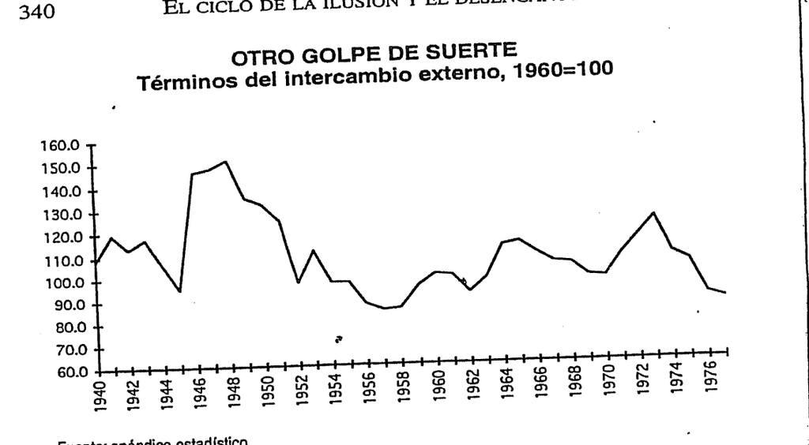

- Un aumento permite comprar más importaciones con una misma cantidad exportada. No garantiza que esa mejora dure.

Gerchunoff y Llach (2007), p. 340, con datos de su apéndice. Términos del intercambio: relación entre índices de precios de exportación e importación.

## [1.5] El proyecto de Gelbard

| Área | Orientación | Finalidad |
| --- | --- | --- |
| **Ingresos** | Recomposición salarial y concertación | Redistribuir y estabilizar |
| **Industria** | Protección, crédito y apoyo a empresas nacionales | Ampliar producción y empleo |
| **Exportaciones** | Promoción manufacturera y nuevos mercados | Reducir la restricción externa |
| **Finanzas** | Centralización de depósitos | Orientar el crédito |
| **Capital extranjero** | Regulación y condiciones de entrada | Subordinarlo a prioridades nacionales |

Gerchunoff y Llach (2007), pp. 337–342. Orientaciones anunciadas: su aplicación y sus resultados fueron desiguales.

## [1.6] ¿Volver a 1946?

- Había continuidades: alianza entre trabajadores y empresarios nacionales, intervención estatal y propósito redistributivo.
- Pero el punto de partida era distinto. En 1973 existía una industria más compleja, una economía acostumbrada a la inflación y un sistema financiero con más alternativas.
- La promoción de **exportaciones industriales** y la búsqueda de nuevos mercados reconocían límites de una expansión apoyada sólo en el consumo interno.

**Instituciones parecidas, economía distinta**

Repetir el nombre de una política no asegura repetir su mecanismo ni sus resultados. La comparación con 1946 es especialmente útil para estudiar la reforma bancaria.

Gerchunoff y Llach (2007), pp. 338–342; Arnaudo (1986), cap. 6, sección sobre renacionalización de depósitos.

## [1.7] El agro y los mercados

- Se ampliaron las atribuciones de las juntas de granos y carnes. La aspiración de centralizar el comercio exterior encontró límites administrativos.
- El impuesto a la renta potencial buscaba premiar indirectamente una utilización más productiva de la tierra. El proyecto de Ley Agraria generó resistencias y no se convirtió en ley.
- Los acuerdos con países socialistas diversificaron destinos de exportación. La participación de esos países pasó del **3 % al 11 % entre 1972 y 1976**, según el libro.

Gerchunoff y Llach (2007), pp. 340–341. No confundir proyectos con normas sancionadas, ni atribuir toda la diversificación comercial a un solo instrumento.

# Bloque 2. Los depósitos

## [2.1] Qué se nacionalizaba

- Los bancos recibían depósitos **por cuenta del Banco Central**. Conservaban funciones operativas de atención, captación y gestión de préstamos.
- El crédito se instrumentaba mediante redescuentos del BCRA. El objetivo era reforzar el control sobre su volumen y orientación.
- No se trataba de quitarle al ahorrista la titularidad de su saldo ni de convertir automáticamente a todos los bancos privados en empresas públicas.

**La pregunta institucional**

¿Quién decide cuánto puede prestar cada banco y a qué actividades? Ése es el centro del régimen, más allá de la etiqueta de nacionalización.

Arnaudo (1986), cap. 6, pp. 97–103 según programa; escaneo local, sección «Renacionalización de los depósitos», hojas VI.14–VI.17. Gerchunoff y Llach (2007), p. 342.

## [2.2] El circuito del crédito

- El banco cobraba una remuneración por su función intermediaria.
- La centralización formal no eliminaba los incentivos a captar depósitos ni la existencia de operaciones fuera del segmento más regulado.

## [2.3] 1946 y 1973

| Dimensión | Experiencia de 1946 | Experiencia de 1973 |
| --- | --- | --- |
| **Forma jurídica** | Depósitos centralizados | Se retoma la centralización |
| **Remuneración bancaria** | Mayor referencia a costos incurridos | Comisiones por categoría y región |
| **Captación y préstamos** | Se busca separar la capacidad de prestar de los depósitos | El redescuento mantiene vínculos con la captación |
| **Contexto financiero** | Menor desarrollo de alternativas | Aceptaciones y otros instrumentos limitan el alcance del control |

**La crítica de Arnaudo**

En 1973, la reforma fue **híbrida**. El cambio jurídico no deshizo la relación económica entre captar fondos y prestar.

Arnaudo (1986), hojas VI.14–VI.16 del escaneo. El autor remite a su comparación publicada en el Boletín del CEMLA, XXI (4), abril de 1975.

## [2.4] El límite del control

- Si el crédito autorizado a cada entidad depende de los depósitos que capta, se conserva un incentivo a competir por esos fondos.
- Los intermediarios participaron en el mercado de **aceptaciones**, un segmento que no quedaba sujeto al mismo control que el crédito bancario regulado.
- En 1974 se incorporaron certificados de depósito con mayores rendimientos y efectos sobre la capacidad prestable. El sistema siguió adaptándose a la inflación y a las restricciones.

**Controlar una parte del sistema**

Un control más estricto sobre el segmento regulado puede coexistir con menor control sobre el conjunto, si crecen las operaciones que lo eluden o tienen reglas distintas.

Arnaudo (1986), hojas VI.15–VI.17 del escaneo local. No se equipara todo el mercado de aceptaciones con intermediación ilegal.

## [2.5] Crédito y distribución

- Una tasa regulada baja puede abaratar el crédito para actividades prioritarias. Con inflación alta, también puede volver muy negativo el rendimiento real de los ahorros.
- La asignación depende entonces no sólo del precio del préstamo, sino de cupos, acceso y decisiones administrativas.
- Si algunos tomadores obtienen crédito barato y lo colocan en activos de mayor rendimiento, el subsidio puede apartarse del destino productivo buscado.

Arnaudo (1986), cap. 6; Gerchunoff y Llach (2007), pp. 342 y 358–360. Conexión con el diagnóstico que precedió a la reforma de 1977.

## Balance de la clase 23

1. El retorno del peronismo combinó una amplia expectativa política con una coyuntura externa favorable.
2. El proyecto de Gelbard buscó crecimiento, redistribución y exportaciones con mayor intervención estatal.
3. La nacionalización de depósitos modificó reglas formales, pero conservó incentivos y segmentos que limitaban el control efectivo.

**La conexión con la estabilización**

Orientar el crédito no resolvía por sí solo la inflación. Faltaba coordinar salarios, precios, tarifas y expectativas: ésa era la tarea inmediata del Pacto Social.

# Bloque 3. El Pacto Social

## [3.1] El diagnóstico

- El programa entendía la inflación como parte de un conflicto por la distribución: cada sector intentaba recuperar ingresos mediante nuevos aumentos.
- Empresarios que anticipaban mayores costos remarcaban antes de que éstos se materializaran. Los sindicatos reclamaban compensaciones para defender el salario real.
- El acuerdo debía interrumpir esa secuencia y establecer una distribución aceptada, con respaldo político suficiente para hacerla cumplir.

**La distinción de Arnaudo**

Los **mecanismos de propagación** explican cómo un aumento se transmite y se repite. Las **presiones inflacionarias** pueden subsistir aunque temporalmente se frene esa transmisión.

Gerchunoff y Llach (2007), pp. 342–343; Arnaudo (1979), pp. 27–33.

## [3.2] Las medidas iniciales

| Instrumento | Compromiso de 1973 |
| --- | --- |
| **Salarios** | Aumento de 200 pesos ley mensuales y salario mínimo de 1.000 |
| **Precios privados** | Congelamiento y revisión de aumentos injustificados |
| **Tarifas** | Ajuste inicial y posterior congelamiento |
| **Negociación salarial** | Sustitución de ajustes descentralizados por reglas del acuerdo |
| **Crédito** | Reducción de tasas y financiamiento para mayores remuneraciones |
| **Cambio** | Estabilidad cambiaria y controles |

Arnaudo (1979), pp. 30–31, reproducción del Acta de Compromiso Nacional. El aumento salarial no debía trasladarse a precios; el reajuste tarifario tenía tratamiento diferente.

## [3.3] Una suma fija

| Salario previo | Aumento | Nuevo salario | Variación |
| --- | --- | --- | --- |
| **1.000** | 200 | 1.200 | 20 % |
| **2.000** | 200 | 2.200 | 10 % |
| **4.000** | 200 | 4.200 | 5 % |

- Una suma uniforme produce una mejora porcentual mayor en los salarios bajos y comprime diferencias entre categorías.
- Si los precios permanecen estables, el aumento nominal se convierte en aumento real. Si luego suben, parte de la mejora se pierde.

Ejemplo didáctico en pesos ley a partir del aumento de 200 del Acta. Los salarios iniciales son ilustrativos. Arnaudo (1979), pp. 30 y 49–51.

## [3.4] El acuerdo y sus límites

| Parte | Qué obtenía | Qué resignaba |
| --- | --- | --- |
| **Trabajadores** | Recomposición inicial y defensa del poder de compra | Autonomía inmediata de negociación salarial |
| **Empresas** | Demanda y menor incertidumbre | Traslado libre de costos a precios |
| **Gobierno** | Coordinación y legitimidad | Margen para cambiar tarifas y otras pautas |

- La autoridad de Perón ayudaba a arbitrar. Pero el acuerdo exigía que cada parte aceptara costos mientras esperaba beneficios futuros.

Gerchunoff y Llach (2007), pp. 343–344; Arnaudo (1979), pp. 30–33.

## [3.5] El éxito inicial

- La inflación se frenó bruscamente durante el segundo semestre de 1973. Los índices registraron pequeñas variaciones e incluso bajas puntuales.
- El PBI creció **4,5 % en 1973**. El desempleo del Gran Buenos Aires descendió, según el libro, de **6,1 % a 4,5 %**.
- La mejora externa permitió sostener importaciones sin repetir inmediatamente el freno de divisas de expansiones anteriores.

**Cuidado con el promedio del año**

Una inflación anual elevada puede coexistir con estabilidad durante el segundo semestre si el aumento de precios se concentró en el primero. Hay que mirar **cuándo** ocurrió.

Gerchunoff y Llach (2007), pp. 344–345; Arnaudo (1979), p. 32. El desempleo citado corresponde al Gran Buenos Aires, no al total nacional.

## [3.6] Más pesos, menos inflación

[figure not shown]

- Gerchunoff y Llach registran un aumento del efectivo y los depósitos desde **9,3 % a 12,1 % del PBI** entre principios y fines de 1973.
- Esa absorción de pesos era una oportunidad de transición. No podía aumentar indefinidamente ni sobrevivir intacta a una pérdida de confianza.

Gerchunoff y Llach (2007), p. 345; Arnaudo (1979), pp. 34–37. Diagrama didáctico de demanda de dinero.

## [3.7] Propagación y presiones

| Problema | Qué lo muestra | Qué exigía |
| --- | --- | --- |
| **Propagación** | Remarcaciones anticipadas y compensaciones sucesivas | Coordinación de precios y salarios |
| **Demanda** | Consumo y gasto creciendo frente a la oferta disponible | Consistencia entre gasto, producción y ahorro |
| **Costos externos** | Encarecimiento de insumos importados | Regla de ajuste y reparto de la pérdida |
| **Precios relativos** | Márgenes muy distintos bajo precios congelados | Revisiones oportunas y selectivas |

**La tesis de Arnaudo**

Atacar la propagación era razonable al comienzo. El problema fue tratar ese éxito como sustituto de una política para las presiones y desajustes que seguían presentes.

Arnaudo (1979), pp. 31–39.

## [3.8] Congelar las diferencias

- Al iniciarse el congelamiento, algunas empresas ya habían remarcado y otras todavía no. La inflación previa no había movido todos los precios al mismo tiempo.
- Congelar ese corte temporal fijaba márgenes y posiciones relativas diferentes. Una empresa podía conservar holgura y otra quedar sin cubrir costos.
- Los aumentos salariales, tarifarios y de insumos tampoco afectaban a todas por igual. El problema podía aparecer como escasez, menor producción o sobreprecios.

**La foto no era un equilibrio**

Que todos los precios dejaran de moverse no significaba que la relación entre ellos fuera sostenible.

Arnaudo (1979), pp. 32–33 y 37–38.

## [3.9] El costo del crédito

- La tasa nominal bajó, pero no tanto como la inflación. Al estabilizarse los precios, aumentó el costo **real** del financiamiento.
- Eso podía moderar inversión y demanda al comienzo. También complicaba a empresas acostumbradas a financiarse con tasas reales negativas.
- Arnaudo cuestiona que la revisión de las tasas llegara tarde, cuando los precios ya volvían a aumentar.

**Otro efecto de la desinflación**

Con interés nominal de 15 %, pasar de inflación de 30 % a 0 % lleva la tasa real de **−11,5 % a +15 %**. No hizo falta subir la tasa nominal.

Arnaudo (1979), pp. 33 y 43–44. Ejemplo ilustrativo: $r=(1+i)/(1+\pi)-1$, tasas del mismo período.

## [3.10] La demanda se recupera

- La mejora del ingreso real no se convirtió toda en consumo inmediatamente. Parte se mantuvo al comienzo en depósitos y otros saldos financieros.
- Con el tiempo creció el gasto. Arnaudo registra aumentos interanuales del consumo cercanos a **10 % en el último trimestre de 1973** y **7,6 % en el primero de 1974**.
- La oferta crecía, pero no garantizaba absorber toda la demanda adicional. El déficit fiscal y los planes de gasto reforzaban esa presión.

Arnaudo (1979), pp. 36–39. Las cifras comparan cada trimestre con el mismo trimestre del año anterior; no son tasas trimestrales consecutivas.

# Bloque 4. La ruptura

## [4.1] El shock importado

- El encarecimiento internacional de insumos y energía elevó costos que el gobierno argentino no controlaba.
- Mantener precios finales congelados obligaba a absorber el aumento en márgenes, salarios reales o cuentas públicas.
- Los subsidios a importaciones intentaron amortiguar el golpe. Consumían recursos y requerían decidir qué productos y empresas recibirían protección.

**Alguien absorbe el costo**

Un acuerdo interno puede distribuir el costo de un shock externo. No puede impedir que un insumo comprado afuera cueste más recursos reales.

Gerchunoff y Llach (2007), p. 346; Arnaudo (1979), pp. 35–39.

## [4.2] Las opciones del pacto

| Respuesta al insumo más caro | Efecto inmediato | Costo o dificultad |
| --- | --- | --- |
| **Empresa absorbe** | Precio final estable | Menor margen y posible caída de oferta |
| **Precio sube** | Recuperación del margen | Menor salario real y nuevos reclamos |
| **Estado subsidia** | Se modera el precio al usuario | Mayor necesidad de recursos fiscales |
| **Mejora productividad** | Menor costo por unidad | Requiere tiempo e inversión |

- Compensar después todos los ingresos nominales puede reiniciar la secuencia de ajustes si no aumentan los recursos disponibles.

Síntesis didáctica a partir de Arnaudo (1979), pp. 35–39. Alternativas analíticas, no opciones igualmente factibles en cada sector.

## [4.3] Marzo de 1974

- La revisión se adelantó respecto del calendario original. La gran paritaria nacional autorizó ajustes salariales, tarifarios y de precios.
- Arnaudo registra un aumento salarial general de **13 %**, vigente desde abril, y discute la consistencia de sus componentes y de las compensaciones a empresas.
- Flexibilizar era necesario. La dificultad consistía en corregir distorsiones sin reconstruir una carrera general de precios y salarios.

**Revisar no basta**

Importaban la frecuencia de las revisiones, los criterios usados y su administración. Un control universal de precios que cambian continuamente era mucho más difícil de aplicar.

Arnaudo (1979), pp. 40–44; Gerchunoff y Llach (2007), p. 346.

## [4.4] Crecimiento con tensiones

- En **1974**, el PBI aumentó **6,7 %** según Gerchunoff y Llach. La expansión coexistía con más inflación y deterioro externo.
- Los reclamos salariales y las dificultades de abastecimiento mostraban que la coordinación inicial se estaba debilitando.
- La muerte de Perón, el **1 de julio de 1974**, quitó al pacto su principal árbitro. La restricción europea a la carne y la recesión internacional agravaron el frente externo.

**Política y economía se reforzaban**

La pérdida de autoridad dificultaba corregir desequilibrios. Los desequilibrios, a su vez, hacían más costoso sostener el acuerdo político.

Gerchunoff y Llach (2007), pp. 346–347.

## [4.5] La salida de Gelbard

- Durante la segunda mitad de 1974, **Gómez Morales** reemplazó a Gelbard e intentó correcciones graduales de precios, salarios y cuentas públicas.
- El atraso de algunos precios y el deterioro externo exigían cambios, pero cada corrección tenía costos distributivos y resistencias dentro del gobierno.
- La conducción económica perdió continuidad. La disputa entre el sindicalismo y el entorno de López Rega atravesó la selección de ministros y las decisiones de política.

Gerchunoff y Llach (2007), pp. 347–349; Arnaudo (1979), pp. 44–48.

## [4.6] El Rodrigazo

- En **junio de 1975**, Celestino Rodrigo impulsó una fuerte corrección del dólar y las tarifas, junto con liberación de precios.
- Los ingresos nominales de los trabajadores quedaron inicialmente rezagados frente al salto de precios. La disputa por las paritarias se volvió decisiva.
- El programa no consiguió consolidar la redistribución que implicaban esos cambios. La reacción sindical forzó nuevas negociaciones y la salida de Rodrigo y López Rega.

**Más que una devaluación**

El episodio combinó una corrección de precios relativos con una crisis de autoridad para decidir quién soportaría el ajuste.

Gerchunoff y Llach (2007), pp. 348–349; Arnaudo (1979), pp. 48–52. Había distintos tipos de cambio y tarifas: no se les atribuye un único porcentaje de aumento.

## [4.7] Las paritarias de 1975

- Arnaudo destaca la concentración temporal de negociaciones que antes se distribuían a lo largo de períodos más extensos.
- Cada sindicato observaba lo obtenido por otros y buscaba evitar quedar rezagado. La expectativa de ajustes aceleró la demanda de nuevas compensaciones.
- Parte de los empresarios aceptaba mayores salarios esperando trasladarlos a precios o recibir financiamiento. Se debilitaba el freno que suponía absorber el aumento en sus márgenes.

**La velocidad importa**

Un mismo mecanismo de comparación y compensación puede producir una dinámica mucho más intensa si se comprime el tiempo entre negociaciones.

Arnaudo (1979), pp. 49–52. Interpretación del mecanismo de propagación, no atribución exclusiva de la crisis a los salarios.

## [4.8] La espiral reaparece

[figure not shown]

- Para que el aumento inicial no se volviera inflación persistente hacía falta una coordinación compatible con el financiamiento, la oferta y la distribución.
- La ruptura del pacto había debilitado justamente esa capacidad de coordinación.

Elaboración didáctica a partir de Arnaudo (1979), pp. 48–52, y Gerchunoff y Llach (2007), pp. 348–349.

## [4.9] La salida hacia 1976

- La política pasó de prometer estabilidad a intentar administrar reajustes. Con Cafiero ganaron terreno las reglas de actualización de salarios, dólar y deuda pública.
- La indexación podía evitar pérdidas abruptas entre revisiones, pero también incorporaba la inflación pasada en decisiones futuras.
- La crisis externa y fiscal continuó. Mondelli recibió una conducción económica sin credibilidad, poco antes del golpe de marzo de 1976.

**El puente al Proceso**

La dictadura recibió desequilibrios graves. Eso ayuda a explicar su punto de partida, pero no determina ni justifica las políticas que eligió después.

Gerchunoff y Llach (2007), pp. 349–350.

## [4.10] Dos lecturas

| Pregunta | Gerchunoff y Llach | Arnaudo |
| --- | --- | --- |
| **¿Por qué arrancó bien?** | Acuerdo político, expectativas y holgura externa | Interrupción de remarcaciones y absorción financiera |
| **¿Qué lo debilitó?** | Shocks externos y erosión de la coalición | Presiones de demanda y precios relativos congelados |
| **¿Qué falló al revisar?** | Menor autoridad para arbitrar | Demoras, reglas de ajuste y administración del control |
| **¿Qué estudiar del final?** | Disgregación del gobierno | Aceleración de la propagación en las paritarias |

Síntesis de énfasis, no oposición excluyente: Gerchunoff y Llach (2007), pp. 337–349; Arnaudo (1979), pp. 25–52. Ambos incorporan factores económicos y políticos.

# Cierre

## Ideas fuerza

1. El Pacto Social combinó **estabilización y redistribución** con una coalición que debía sostener ambas.
2. El éxito inicial tuvo mecanismos económicos: expectativas, remonetización y un contexto externo favorable.
3. La centralización de depósitos no aseguró control efectivo sobre todo el sistema financiero.
4. Congelar precios no resolvió las presiones de demanda ni las diferencias de costos y márgenes.
5. La demora en revisar el esquema, los shocks externos y la pérdida de autoridad política desembocaron en una crisis de coordinación.

## Preguntas para llevarse

- ¿Por qué una suma salarial fija modifica los diferenciales entre categorías?
- ¿Cómo puede aumentar el dinero sin aumentar inmediatamente los precios?
- ¿Qué diferencia hay entre propagación y presiones inflacionarias?
- ¿Por qué la reforma bancaria de 1973 no reprodujo mecánicamente la de 1946?
- ¿Quién absorbe el costo de un insumo importado más caro si se congelan los precios?
- ¿Por qué el Rodrigazo no aseguró una corrección estable de precios relativos?

## Lecturas principales

- **Gerchunoff, P. y Llach, L. (2007).** *El ciclo de la ilusión y el desencanto*, cap. 8, especialmente **pp. 334–349**.
- **Arnaudo, A. A. (1979).** «El programa antiinflacionario de 1973». *Desarrollo Económico*, **19 (73), 25–52**. Leer medidas iniciales, flexibilización y análisis de las paritarias de 1975.
- **Arnaudo, A. (1986).** *Cincuenta años de política financiera argentina, 1934–1983*, cap. 6, **pp. 97–103** en la referencia del programa. El escaneo local conserva numeración de capítulo y cuadros separados.

Las tres lecturas están en «HEA-parte 3-Cap 6.pdf». Para la comparación bancaria, el libro remite además a Arnaudo (1975), «La nacionalización de los depósitos en Argentina. Análisis comparativo de los sistemas de 1946 y 1973», Boletín del CEMLA, XXI (4).